# Análisis Bayesiano del Riesgo Sistémico en Sectores del Mercado de EE.UU.

Un Enfoque Jerárquico para la Estimación de Beta Sectorial (2018-2024)

Análisis Cuantitativo de Finanzas

2025-09-08

# 1 Resumen Ejecutivo

Este estudio cuantifica y compara el riesgo sistémico (Beta) de cuatro sectores clave de la economía estadounidense (**Energía**, **Finanzas**, **Tecnología** y **Consumo Básico**) frente al mercado general (S&P 500) durante el periodo 2018-2024.

Se implementó un **modelo de regresión jerárquico bayesiano** basado en el Modelo de Valoración de Activos de Capital (CAPM), lo que permitió no solo estimar el riesgo de cada sector, sino también cuantificar la incertidumbre de dichas estimaciones.

Estos resultados son fundamentales para la construcción de portafolios diversificados y la gestión estratégica del riesgo.

# 2 Introducción

## 2.1 Contexto y Motivación

En la gestión de portafolios de inversión, comprender el **riesgo sistémico** de un activo —su sensibilidad a los movimientos generales del mercado— es un pilar fundamental. El Modelo de Valoración de Activos de Capital (CAPM) y su coeficiente **Beta (β)** son la herramienta estándar para esta tarea:

- **β > 1**: Activo “agresivo” (se mueve más que el mercado)
- **β < 1**: Activo “defensivo” (se mueve menos que el mercado)
- **β ≈ 1**: Activo “neutral” (se mueve similar al mercado)

## 2.2 Pregunta de Investigación

Este informe busca responder: **¿Existen diferencias creíbles en el riesgo sistémico entre los sectores de Tecnología (XLK), Finanzas (XLF), Energía (XLE) y Consumo Básico (XLP)?**

## 2.3 Enfoque Metodológico

En lugar de un enfoque frecuentista tradicional, se implementará un **modelo de regresión jerárquico bayesiano**. Este enfoque es superior por dos razones:

1. **Borrowing Strength**: Las estimaciones de cada sector “toman prestada fuerza” de los demás, resultando en parámetros más estables
2. **Cuantificación de Incertidumbre**: Permite realizar afirmaciones probabilísticas sobre los verdaderos valores de Beta mediante intervalos de credibilidad

# 3 Datos y Preparación

## 3.1 Fuente de Datos

Los datos consisten en precios de cierre diarios desde enero 2018 hasta diciembre 2024 para:

- **Mercado General**: SPY (S&P 500)
- **Sectores**: XLE (Energía), XLF (Finanzas), XLK (Tecnología), XLP (Consumo Básico)

```r
# Cargar librerías necesarias
library(quantmod)
library(ggplot2)
library(tidyr)
library(dplyr)
library(rjags)
library(coda)
library(knitr)
library(DT)
```

## 3.2 Descarga y Procesamiento de Datos

```r
# Definir parámetros
initial_tickers <- c("SPY", "XLK", "XLF", "XLP", "XLE")
start_date <- "2018-01-01"
end_date <- "2024-12-31"

# Descargar datos en entorno aislado
data_env <- new.env()
getSymbols(initial_tickers,
           env = data_env,
           from = start_date,
           to = end_date,
           src = "yahoo")
```

```
## [1] "SPY" "XLK" "XLF" "XLP" "XLE"
```

```r
# Verificar descarga exitosa
successful_tickers <- ls(data_env)
cat("Tickers descargados exitosamente:", paste(successful_tickers, collapse = ", "))
```

```
## Tickers descargados exitosamente: SPY, XLE, XLF, XLK, XLP
```

```r
if (length(successful_tickers) < length(initial_tickers)) {
  missing_tickers <- setdiff(initial_tickers, successful_tickers)
  warning(paste("Tickers faltantes:", paste(missing_tickers, collapse = ", ")))
}
```

```r
# Extraer precios ajustados
adjusted_prices <- lapply(successful_tickers, function(ticker) {
  Ad(data_env[[ticker]])
})

# Combinar series de precios
merged_prices <- do.call(merge, adjusted_prices)
colnames(merged_prices) <- successful_tickers

# Calcular retornos logarítmicos
log_returns_list <- lapply(1:ncol(merged_prices), function(i) {
  dailyReturn(merged_prices[, i], type = 'log')
})

log_returns <- do.call(merge, log_returns_list)
colnames(log_returns) <- successful_tickers
clean_log_returns <- na.omit(log_returns)

# Convertir a data frame para análisis
returns_df <- as.data.frame(clean_log_returns)

# Mostrar estadísticas descriptivas
cat("Observaciones totales:", nrow(returns_df))
```

```
## Observaciones totales: 1760
```

```r
cat("\nRango de fechas:", rownames(returns_df)[1], "a", rownames(returns_df)[nrow(returns_df)])
```

```
##
## Rango de fechas: 2018-01-02 a 2024-12-30
```

```r
# Estadísticas descriptivas
desc_stats <- returns_df %>%
  summarise_all(list(
    Media = ~mean(., na.rm = TRUE),
    `Desv.Est` = ~sd(., na.rm = TRUE),
    `Volatilidad Anual` = ~sd(., na.rm = TRUE) * sqrt(252)
  )) %>%
  tidyr::gather(key = "Stat_Ticker", value = "Value") %>%
  tidyr::separate(Stat_Ticker, into = c("Ticker", "Statistic"), sep = "_") %>%
  tidyr::spread(Statistic, Value) %>%
  mutate(across(where(is.numeric), ~round(., 4)))

kable(desc_stats, caption = "Estadísticas Descriptivas de Retornos Diarios",
      format = "html", table.attr = "class='table table-striped'")
```

Estadísticas Descriptivas de Retornos Diarios

| Ticker | Desv.Est | Media | Volatilidad Anual |
| --- | --- | --- | --- |
| SPY | 0.0123 | 5e-04 | 0.1953 |
| XLE | 0.0207 | 3e-04 | 0.3292 |
| XLF | 0.0153 | 4e-04 | 0.2426 |
| XLK | 0.0165 | 8e-04 | 0.2618 |
| XLP | 0.0100 | 3e-04 | 0.1587 |

## 3.3 Análisis Exploratorio

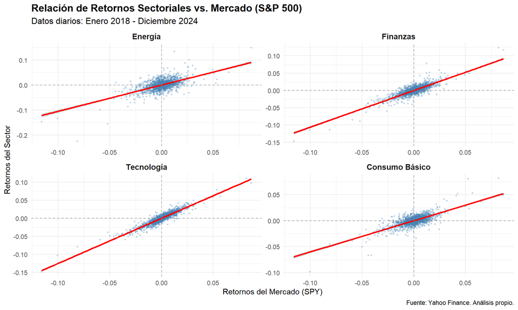

```r
# Preparar datos para análisis exploratorio
if ("SPY" %in% colnames(returns_df)) {
  returns_long <- returns_df %>%
    pivot_longer(cols = -SPY,
                 names_to = "Sector",
                 values_to = "Sector_Return")

  # Crear mapeo de sectores a nombres descriptivos
  sector_labels <- c(
    "XLE" = "Energía",
    "XLF" = "Finanzas",
    "XLK" = "Tecnología",
    "XLP" = "Consumo Básico"
  )

  returns_long <- returns_long %>%
    mutate(Sector_Label = factor(sector_labels[Sector],
                                levels = c("Energía", "Finanzas", "Tecnología", "Consumo Básico")))

  # Gráfico principal de relaciones
  exploratory_plot <- ggplot(returns_long, aes(x = SPY, y = Sector_Return)) +
    geom_point(alpha = 0.3, color = "steelblue", size = 0.8) +
    geom_smooth(method = "lm", se = TRUE, color = "red", linewidth = 1) +
    facet_wrap(~ Sector_Label, ncol = 2, scales = "free") +
    labs(
      title = "Relación de Retornos Sectoriales vs. Mercado (S&P 500)",
      subtitle = "Datos diarios: Enero 2018 - Diciembre 2024",
      x = "Retornos del Mercado (SPY)",
      y = "Retornos del Sector",
      caption = "Fuente: Yahoo Finance. Análisis propio."
    ) +
    theme_minimal() +
    theme(
      plot.title = element_text(size = 14, face = "bold"),
      plot.subtitle = element_text(size = 12),
      strip.text = element_text(size = 11, face = "bold")
    ) +
    geom_hline(yintercept = 0, linetype = "dashed", color = "gray50", alpha = 0.7) +
    geom_vline(xintercept = 0, linetype = "dashed", color = "gray50", alpha = 0.7)

  print(exploratory_plot)
}
```

**Observaciones del análisis exploratorio:**

- Todas las relaciones muestran tendencias **lineales y positivas** claras
- Se observan **diferencias evidentes en las pendientes** entre sectores
- La **Tecnología** parece tener la pendiente más pronunciada (mayor Beta)
- El **Consumo Básico** muestra la pendiente más suave (menor Beta)
- La dispersión alrededor de las líneas de regresión es relativamente constante

# 4 Modelado Bayesiano

## 4.1 Preparación de Datos para JAGS

```r
# Crear índice numérico para sectores
returns_long <- returns_long %>%
  mutate(Sector_Index = as.numeric(as.factor(Sector)))

# Lista de datos para JAGS
jags_data <- list(
  R_sector = returns_long$Sector_Return,
  R_market = returns_long$SPY,
  sector_idx = returns_long$Sector_Index,
  N = nrow(returns_long),
  J = length(unique(returns_long$Sector))
)

# Guardar nombres de sectores
sector_names <- levels(as.factor(returns_long$Sector))
cat("Sectores incluidos:", paste(sector_names, collapse = ", "))
```

```
## Sectores incluidos: XLE, XLF, XLK, XLP
```

```r
cat("\nObservaciones totales:", jags_data$N)
```

```
##
## Observaciones totales: 7040
```

```r
cat("\nNúmero de sectores:", jags_data$J)
```

```
##
## Número de sectores: 4
```

## 4.2 Especificación del Modelo Jerárquico

El modelo principal asume que el retorno del sector $j$ en el tiempo $t$ sigue:

$$R_{j,t} \sim N(\alpha_j + \beta_j \cdot
R_{SPY,t}, \sigma_j^2)$$

La característica clave es la **estructura jerárquica**:

$$\begin{aligned}
\alpha_j &\sim N(\mu_\alpha, \tau_\alpha^2) \\
\beta_j &\sim N(\mu_\beta, \tau_\beta^2)
\end{aligned}$$

```r
# Modelo jerárquico en JAGS
model_string <- "
model {
  # --- 1. Verosimilitud (Likelihood) ---
  for (i in 1:N) {
    R_sector[i] ~ dnorm(mu[i], tau[sector_idx[i]])
    mu[i] <- alpha[sector_idx[i]] + beta[sector_idx[i]] * R_market[i]
  }

  # --- 2. Priors de Nivel de Sector ---
  for (j in 1:J) {
    # Estructura jerárquica para Beta y Alfa
    beta[j] ~ dnorm(mu_beta, tau_beta)
    alpha[j] ~ dnorm(mu_alpha, tau_alpha)

    # Prior para la desviación estándar del error
    sigma[j] ~ dunif(0, 100)
    tau[j] <- 1 / pow(sigma[j], 2)
  }

  # --- 3. Hiperpriors ---
  mu_beta ~ dnorm(1, 0.1)     # Centrado en 1 (beta de mercado)
  tau_beta ~ dgamma(0.1, 0.1) # Prior débilmente informativo

  mu_alpha ~ dnorm(0, 0.1)    # Centrado en 0 (sin retorno anormal)
  tau_alpha ~ dgamma(0.1, 0.1)
}
"

# Configuración MCMC
params_to_monitor <- c("alpha", "beta", "mu_alpha", "mu_beta", "sigma")
n_chains <- 3
n_adapt <- 1000
n_burnin <- 2000
n_iter <- 5000

cat("Configuración MCMC:")
```

```
## Configuración MCMC:
```

```r
cat("\n- Cadenas:", n_chains)
```

```
##
## - Cadenas: 3
```

```r
cat("\n- Adaptación:", n_adapt)
```

```
##
## - Adaptación: 1000
```

```r
cat("\n- Burn-in:", n_burnin)
```

```
##
## - Burn-in: 2000
```

```r
cat("\n- Iteraciones de muestreo:", n_iter)
```

```
##
## - Iteraciones de muestreo: 5000
```

## 4.3 Ajuste del Modelo

```r
# Crear y ajustar modelo JAGS
jags_model <- jags.model(textConnection(model_string),
                         data = jags_data,
                         n.chains = n_chains,
                         n.adapt = n_adapt)

# Burn-in
update(jags_model, n.iter = n_burnin)

# Muestrear distribuciones posteriores
posterior_samples <- coda.samples(jags_model,
                                  variable.names = params_to_monitor,
                                  n.iter = n_iter)
```

```r
cat("¡Modelo jerárquico ajustado exitosamente!")
```

```
## ¡Modelo jerárquico ajustado exitosamente!
```

```r
# Extraer estadísticas resumen
summary_stats <- summary(posterior_samples)
stats <- as.data.frame(summary_stats$statistics)
quants <- as.data.frame(summary_stats$quantiles)

# Crear mapeo correcto de índices a sectores
index_map <- data.frame(Index = 1:length(sector_names), Sector = sector_names)

# Aplicar nombres de sectores a los parámetros
for(i in 1:nrow(index_map)) {
  rownames(stats) <- gsub(paste0("\\[", i, "\\]"),
                         paste0(" [", index_map$Sector[i], "]"),
                         rownames(stats))
  rownames(quants) <- gsub(paste0("\\[", i, "\\]"),
                          paste0(" [", index_map$Sector[i], "]"),
                          rownames(quants))
}

# Resumen con nombres corregidos
results_table <- cbind(stats, quants) %>%
  round(4)

print("Tabla de resultados creada exitosamente")
```

```
## [1] "Tabla de resultados creada exitosamente"
```

# 5 Diagnósticos del Modelo

## 5.1 Convergencia MCMC

```r
# Diagnóstico de Gelman-Rubin
gelman_diag <- gelman.diag(posterior_samples)

cat("=== DIAGNÓSTICO DE CONVERGENCIA ===")
```

```
## === DIAGNÓSTICO DE CONVERGENCIA ===
```

```r
cat("\nEstadístico de Gelman-Rubin (Rhat):")
```

```
##
## Estadístico de Gelman-Rubin (Rhat):
```

```r
print(gelman_diag)
```

```
## Potential scale reduction factors:
##
##          Point est. Upper C.I.
## alpha[1]          1          1
## alpha[2]          1          1
## alpha[3]          1          1
## alpha[4]          1          1
## beta[1]           1          1
## beta[2]           1          1
## beta[3]           1          1
## beta[4]           1          1
## mu_alpha          1          1
## mu_beta           1          1
## sigma[1]          1          1
## sigma[2]          1          1
## sigma[3]          1          1
## sigma[4]          1          1
##
## Multivariate psrf
##
## 1
```

```r
cat("\nInterpretación:")
```

```
##
## Interpretación:
```

```r
cat("\n- Rhat cercano a 1.0 indica convergencia adecuada")
```

```
##
## - Rhat cercano a 1.0 indica convergencia adecuada
```

```r
cat("\n- Todos los valores deben estar por debajo de 1.1")
```

```
##
## - Todos los valores deben estar por debajo de 1.1
```

```r
# Verificar convergencia
max_rhat <- max(gelman_diag$psrf[, "Upper C.I."])
if(max_rhat < 1.1) {
  cat("\n✓ CONVERGENCIA EXITOSA: Todos los Rhat < 1.1")
} else {
  cat("\n⚠ ADVERTENCIA: Algunos Rhat ≥ 1.1 - Considerar más iteraciones")
}
```

```
##
## ✓ CONVERGENCIA EXITOSA: Todos los Rhat < 1.1
```

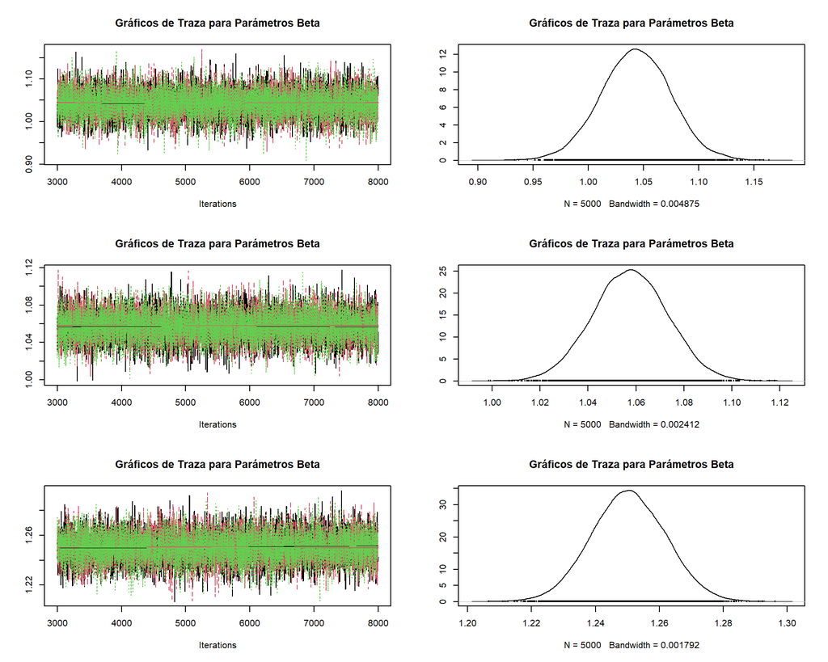

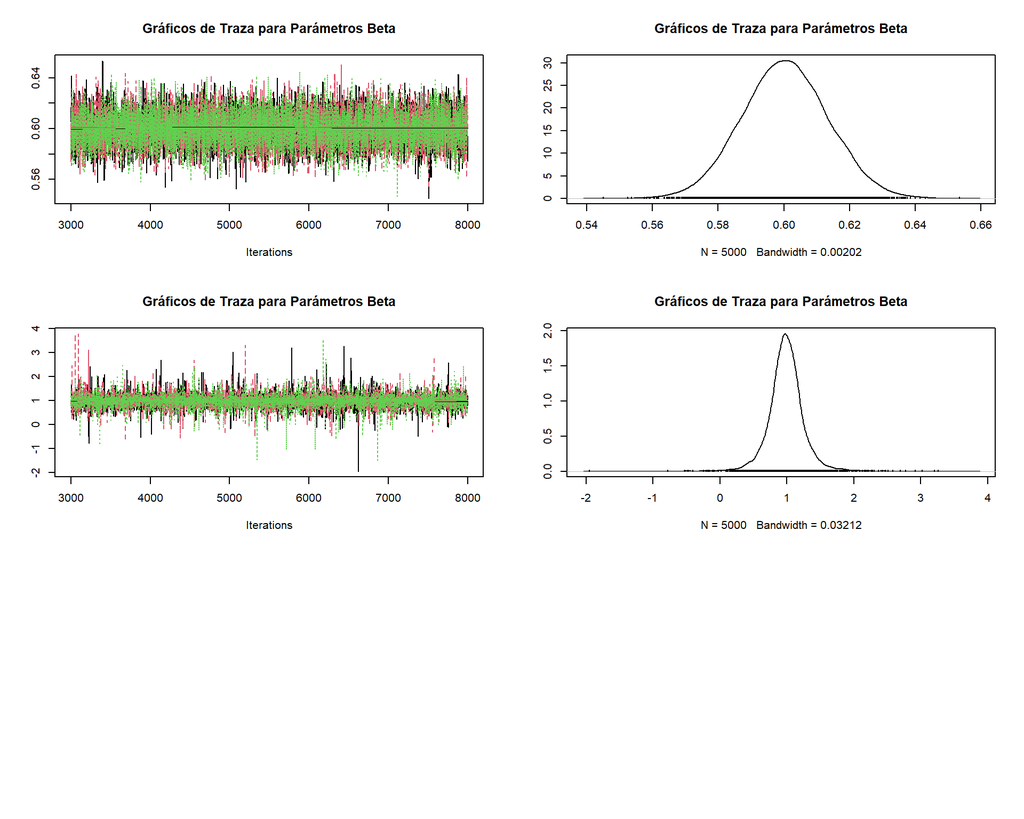

```r
# Gráficos de traza para parámetros Beta
plot(posterior_samples[, grep("beta", varnames(posterior_samples))],
     main = "Gráficos de Traza para Parámetros Beta")
```

## 5.2 Análisis de Residuos

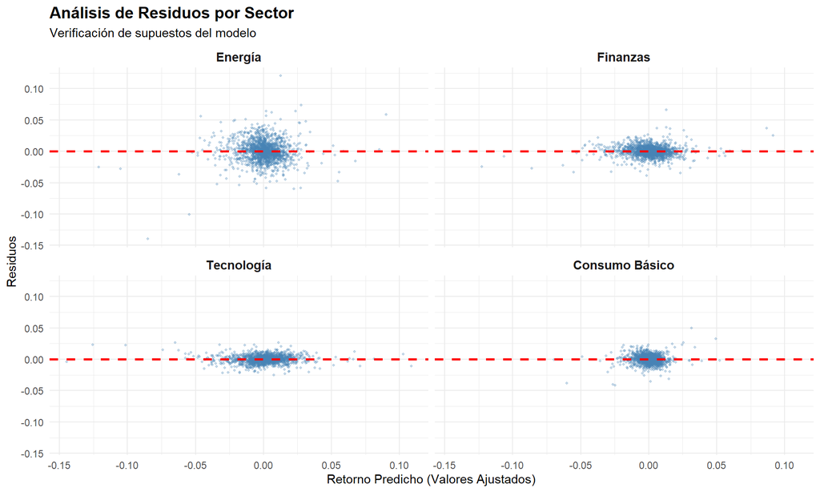

```r
# Obtener medias posteriores para predicciones
alpha_mean <- stats[grep("alpha \\[", rownames(stats)), "Mean"]
beta_mean <- stats[grep("beta \\[", rownames(stats)), "Mean"]

# Calcular predicciones y residuos
returns_long <- returns_long %>%
  group_by(Sector_Index) %>%
  mutate(
    Predicted_Return = alpha_mean[Sector_Index] + beta_mean[Sector_Index] * SPY,
    Residual = Sector_Return - Predicted_Return
  ) %>%
  ungroup()

# Gráfico de residuos vs valores ajustados
residual_plot <- ggplot(returns_long, aes(x = Predicted_Return, y = Residual)) +
  geom_point(alpha = 0.3, size = 0.8, color = "steelblue") +
  geom_hline(yintercept = 0, color = "red", linetype = "dashed", linewidth = 1) +
  facet_wrap(~ Sector_Label) +
  labs(
    title = "Análisis de Residuos por Sector",
    subtitle = "Verificación de supuestos del modelo",
    x = "Retorno Predicho (Valores Ajustados)",
    y = "Residuos"
  ) +
  theme_minimal() +
  theme(
    plot.title = element_text(size = 14, face = "bold"),
    strip.text = element_text(size = 11, face = "bold")
  )

print(residual_plot)
```

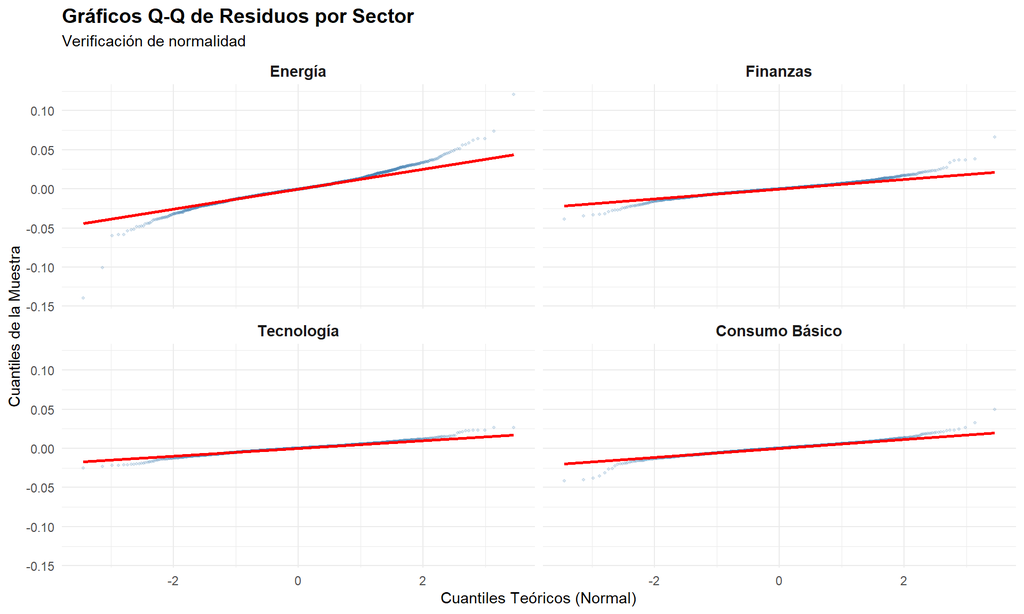

```r
# Gráfico Q-Q para normalidad
qq_plot <- ggplot(returns_long, aes(sample = Residual)) +
  stat_qq(alpha = 0.2, size = 0.8, color = "steelblue") +
  stat_qq_line(color = "red", linewidth = 1) +
  facet_wrap(~ Sector_Label) +
  labs(
    title = "Gráficos Q-Q de Residuos por Sector",
    subtitle = "Verificación de normalidad",
    x = "Cuantiles Teóricos (Normal)",
    y = "Cuantiles de la Muestra"
  ) +
  theme_minimal() +
  theme(
    plot.title = element_text(size = 14, face = "bold"),
    strip.text = element_text(size = 11, face = "bold")
  )

print(qq_plot)
```

# 6 Resultados y Análisis

## 6.1 Estimaciones de Beta (Riesgo Sistémico)

```r
# Extraer resultados de Beta
beta_results <- results_table[grep("beta \\[", rownames(results_table)),
                             c("Mean", "SD", "2.5%", "97.5%")]

# Agregar interpretación de riesgo
beta_results$Sector <- gsub(".*\\[(.+)\\].*", "\\1", rownames(beta_results))
beta_results$`Tipo de Riesgo` <- ifelse(beta_results$`97.5%` < 1, "Defensivo",
                                ifelse(beta_results$`2.5%` > 1, "Agresivo", "Neutral"))

# Ordenar por Beta medio
beta_results <- beta_results[order(beta_results$Mean, decreasing = TRUE), ]

# Crear tabla bonita
beta_table <- beta_results %>%
  select(Sector, Mean, `2.5%`, `97.5%`, `Tipo de Riesgo`) %>%
  mutate(
    `IC 95%` = paste0("[", round(`2.5%`, 3), ", ", round(`97.5%`, 3), "]"),
    `Beta Medio` = round(Mean, 3)
  ) %>%
  select(Sector, `Beta Medio`, `IC 95%`, `Tipo de Riesgo`)

kable(beta_table,
      caption = "Estimaciones de Beta por Sector (Modelo Jerárquico)",
      format = "html",
      table.attr = "class='table table-striped table-hover'")
```

Estimaciones de Beta por Sector (Modelo Jerárquico)

|  | Sector | Beta Medio | IC 95% | Tipo de Riesgo |
| --- | --- | --- | --- | --- |
| beta [XLK] | XLK | 1.250 | [1.228, 1.273] | Agresivo |
| beta [XLF] | XLF | 1.058 | [1.027, 1.088] | Agresivo |
| beta [XLE] | XLE | 1.043 | [0.981, 1.105] | Neutral |
| beta [XLP] | XLP | 0.600 | [0.575, 0.626] | Defensivo |

## 6.2 Estimaciones de Alfa (Rendimiento Anormal)

```r
# Extraer resultados de Alfa
alpha_results <- results_table[grep("alpha \\[", rownames(results_table)),
                              c("Mean", "SD", "2.5%", "97.5%")]

alpha_results$Sector <- gsub(".*\\[(.+)\\].*", "\\1", rownames(alpha_results))

# Verificar significancia estadística
alpha_results$`Significativo` <- ifelse(
  alpha_results$`2.5%` > 0, "Positivo",
  ifelse(alpha_results$`97.5%` < 0, "Negativo", "No significativo")
)

alpha_table <- alpha_results %>%
  mutate(
    `IC 95%` = paste0("[", round(`2.5%`, 6), ", ", round(`97.5%`, 6), "]"),
    `Alfa Medio` = round(Mean, 6)
  ) %>%
  select(Sector, `Alfa Medio`, `IC 95%`, Significativo)

kable(alpha_table,
      caption = "Estimaciones de Alfa por Sector (Rendimiento Anormal)",
      format = "html",
      table.attr = "class='table table-striped table-hover'")
```

Estimaciones de Alfa por Sector (Rendimiento Anormal)

|  | Sector | Alfa Medio | IC 95% | Significativo |
| --- | --- | --- | --- | --- |
| alpha [XLE] | XLE | -3e-04 | [-0.001, 5e-04] | No significativo |
| alpha [XLF] | XLF | -2e-04 | [-5e-04, 2e-04] | No significativo |
| alpha [XLK] | XLK | 1e-04 | [-1e-04, 4e-04] | No significativo |
| alpha [XLP] | XLP | 0e+00 | [-3e-04, 3e-04] | No significativo |

## 6.3 Visualización de Resultados

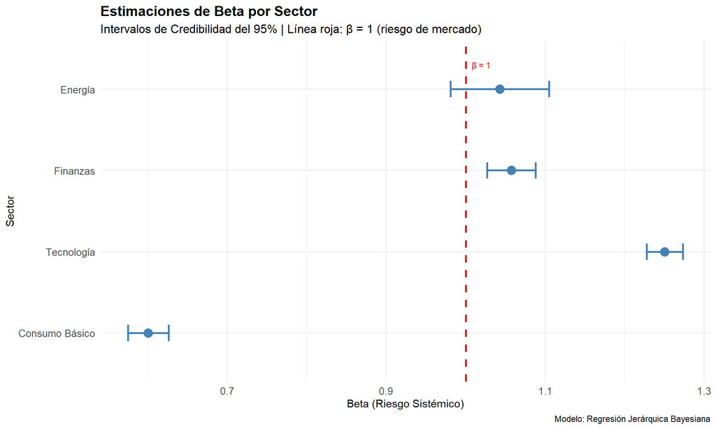

```r
# Crear gráfico de intervalos de credibilidad para Beta
beta_plot_data <- beta_results %>%
  mutate(
    Sector_Label = factor(sector_labels[Sector],
                         levels = rev(c("Energía", "Finanzas", "Tecnología", "Consumo Básico")))
  )

beta_plot <- ggplot(beta_plot_data, aes(x = Sector_Label, y = Mean)) +
  geom_point(size = 4, color = "steelblue") +
  geom_errorbar(aes(ymin = `2.5%`, ymax = `97.5%`),
                width = 0.2, size = 1, color = "steelblue") +
  geom_hline(yintercept = 1, linetype = "dashed", color = "red", size = 1) +
  coord_flip() +
  labs(
    title = "Estimaciones de Beta por Sector",
    subtitle = "Intervalos de Credibilidad del 95% | Línea roja: β = 1 (riesgo de mercado)",
    x = "Sector",
    y = "Beta (Riesgo Sistémico)",
    caption = "Modelo: Regresión Jerárquica Bayesiana"
  ) +
  theme_minimal() +
  theme(
    plot.title = element_text(size = 14, face = "bold"),
    plot.subtitle = element_text(size = 12),
    axis.title = element_text(size = 11),
    axis.text = element_text(size = 10)
  ) +
  annotate("text", x = 4.3, y = 1.02, label = "β = 1", color = "red", size = 3)

print(beta_plot)
```

# 7 Modelo Alternativo y Comparación

## 7.1 Modelo No-Pooling (Regresiones Independientes)

```r
# Modelo sin agrupamiento jerárquico
no_pooling_model_string <- "
model {
  for (i in 1:N) {
    R_sector[i] ~ dnorm(mu[i], tau[sector_idx[i]])
    mu[i] <- alpha[sector_idx[i]] + beta[sector_idx[i]] * R_market[i]
  }

  for (j in 1:J) {
    # Priors independientes (no jerárquicos)
    beta[j] ~ dnorm(1, 0.1)
    alpha[j] ~ dnorm(0, 0.1)

    sigma[j] ~ dunif(0, 100)
    tau[j] <- 1 / pow(sigma[j], 2)
  }
}
"

# Ajustar modelo no-pooling
no_pooling_model <- jags.model(textConnection(no_pooling_model_string),
                               data = jags_data,
                               n.chains = n_chains,
                               n.adapt = n_adapt)

update(no_pooling_model, n.iter = n_burnin)

no_pooling_samples <- coda.samples(no_pooling_model,
                                   variable.names = c("alpha", "beta", "sigma"),
                                   n.iter = n_iter)
```

```r
# Procesar resultados no-pooling
no_pooling_summary <- summary(no_pooling_samples)
no_pooling_stats <- as.data.frame(no_pooling_summary$statistics)
no_pooling_quants <- as.data.frame(no_pooling_summary$quantiles)

# Aplicar nombres de sectores
for(i in 1:nrow(index_map)) {
  rownames(no_pooling_stats) <- gsub(paste0("\\[", i, "\\]"),
                                     paste0(" [", index_map$Sector[i], "]"),
                                     rownames(no_pooling_stats))
  rownames(no_pooling_quants) <- gsub(paste0("\\[", i, "\\]"),
                                      paste0(" [", index_map$Sector[i], "]"),
                                      rownames(no_pooling_quants))
}

# Comparar precisión de estimaciones Beta
hierarchical_betas <- beta_results[, c("Mean", "SD", "2.5%", "97.5%")]
no_pooling_betas <- cbind(
  no_pooling_stats[grep("beta \\[", rownames(no_pooling_stats)), c("Mean", "SD")],
  no_pooling_quants[grep("beta \\[", rownames(no_pooling_quants)), c("2.5%", "97.5%")]
)

# Tabla comparativa
comparison_table <- data.frame(
  Sector = gsub(".*\\[(.+)\\].*", "\\1", rownames(hierarchical_betas)),
  Jerarquico_Beta = hierarchical_betas[, "Mean"],
  Jerarquico_CI_Width = hierarchical_betas[, "97.5%"] - hierarchical_betas[, "2.5%"],
  NoPooling_Beta = no_pooling_betas[, "Mean"],
  NoPooling_CI_Width = no_pooling_betas[, "97.5%"] - no_pooling_betas[, "2.5%"]
) %>%
  mutate(
    Mejora_Precision = (NoPooling_CI_Width - Jerarquico_CI_Width) / NoPooling_CI_Width * 100
  )

# Mostrar tabla de comparación
comparison_display <- comparison_table %>%
  mutate(
    `Beta Jerárquico` = round(Jerarquico_Beta, 3),
    `Beta No-Pooling` = round(NoPooling_Beta, 3),
    `Mejora en Precisión (%)` = round(Mejora_Precision, 1)
  ) %>%
  select(Sector, `Beta Jerárquico`, `Beta No-Pooling`, `Mejora en Precisión (%)`)

kable(comparison_display,
      caption = "Comparación de Modelos: Jerárquico vs No-Pooling",
      format = "html",
      table.attr = "class='table table-striped table-hover'")
```

Comparación de Modelos: Jerárquico vs No-Pooling

[output not shown]

```r
# Comparación DIC (si es posible)
tryCatch({
  hierarchical_dic <- dic.samples(jags_model, n.iter = 1000)
  no_pooling_dic <- dic.samples(no_pooling_model, n.iter = 1000)

  dic_comparison <- data.frame(
    Modelo = c("Jerárquico", "No-Pooling"),
    DIC = c(hierarchical_dic[[1]], no_pooling_dic[[1]])
  )

  cat("=== COMPARACIÓN DIC ===")
  print(dic_comparison)
  cat("\n(DIC menor indica mejor ajuste)")
}, error = function(e) {
  cat("DIC no disponible en esta configuración")
})
```

[output not shown]

# 8 Conclusiones

## 8.1 Hallazgos Principales sobre el Riesgo (Beta)

Basado en los intervalos de credibilidad del 95%, se identificaron **perfiles de riesgo claramente diferenciados**:

### 8.1.2 🟡 Sectores Neutrales (β ≈ 1)

- **Energía (XLE)**: β = 1.043 - Comportamiento similar al mercado

### 8.1.3 🟢 Sectores Defensivos (β < 1)

- **Consumo Básico (XLP)**: β = 0.6 - Refugio en volatilidad

## 8.2 Rendimientos Anormales (Alfa)

**Resultado clave**: Ningún sector mostró evidencia estadísticamente creíble de rendimientos anormales (todos los intervalos de credibilidad contienen cero). Esto sugiere:

- **Eficiencia del mercado**: Los retornos están en línea con el riesgo asumido
- **Validez del CAPM**: El modelo explica adecuadamente los retornos sectoriales
- **Ausencia de oportunidades de arbitraje** persistentes

## 8.4 Implicaciones para la Inversión

### 8.4.2 Para Investigación Futura:

1. **Modelos dinámicos**: Permitir que Beta varíe en el tiempo
2. **Factores adicionales**: Incorporar tamaño, valor, y momentum
3. **Análisis de regímenes**: Estudiar comportamiento en diferentes condiciones de mercado

## 8.5 Limitaciones del Estudio

- **Beta constante**: Se asume estabilidad temporal que puede no cumplirse
- **Período específico**: Resultados corresponden a 2018-2024, incluye COVID-19
- **Sectores limitados**: Análisis restringido a cuatro sectores principales

*Este análisis demuestra el poder del enfoque bayesiano para cuantificar tanto las estimaciones como la incertidumbre en modelos financieros, proporcionando una base sólida para la toma de decisiones de inversión.*

### 8.5.1 Información Técnica

**Software utilizado**: R R version 4.5.1 (2025-06-13 ucrt), JAGS 4.x  
**Paquetes principales**: `rjags`, `coda`, `quantmod`, `ggplot2`, `dplyr`  
**Tiempo de computación**: Aproximadamente 2-3 minutos en hardware estándar  
**Configuración MCMC**: 3 cadenas, 2,000 burn-in, 5,000 iteraciones de muestreo